# Bic Mac Index

Exciting, some economics data. A good break after last week’s dataset.

```r
big_mac <- readr::read_csv('https://raw.githubusercontent.com/rfordatascience/tidytuesday/master/data/2020/2020-12-22/big-mac.csv')
```

```r
skimr::skim(big_mac)
```

```
-- Data Summary ------------------------
                           Values
Name                       big_mac
Number of rows             1386
Number of columns          19
_______________________
Column type frequency:
  character                3
  Date                     1
  numeric                  15
________________________
Group variables            None

-- Variable type: character -------------------------------------------------------------------------------------
# A tibble: 3 x 8
  skim_variable n_missing complete_rate   min   max empty n_unique whitespace
* <chr>             <int>         <dbl> <int> <int> <int>    <int>      <int>
1 iso_a3                0             1     3     3     0       56          0
2 currency_code         0             1     3     3     0       56          0
3 name                  0             1     3    20     0       57          0

-- Variable type: Date ------------------------------------------------------------------------------------------
# A tibble: 1 x 7
  skim_variable n_missing complete_rate min        max        median     n_unique
* <chr>             <int>         <dbl> <date>     <date>     <date>        <int>
1 date                  0             1 2000-04-01 2020-07-01 2013-07-01       33

-- Variable type: numeric ---------------------------------------------------------------------------------------
# A tibble: 15 x 11
   skim_variable n_missing complete_rate       mean         sd       p0       p25         p50        p75
 * <chr>             <int>         <dbl>      <dbl>      <dbl>    <dbl>     <dbl>       <dbl>      <dbl>
 1 local_price           0         1     10043.     181451.       1.05     7.25      24.2       119
 2 dollar_ex             0         1      3818.      69296.       0.302    2.98       7.75       47.1
 3 dollar_price          0         1         3.26        1.26     0.640    2.34       3.04        4.01
 4 usd_raw               0         1        -0.231       0.298   -0.779   -0.446     -0.291      -0.0673
 5 eur_raw               0         1        -0.234       0.273   -0.805   -0.437     -0.277      -0.0712
 6 gbp_raw               0         1        -0.182       0.299   -0.810   -0.401     -0.234       0
 7 jpy_raw               0         1         0.0372      0.390   -0.724   -0.255     -0.00458     0.231
 8 cny_raw               0         1         0.486       0.633   -0.566    0.0485     0.328       0.813
 9 gdp_dollar          684         0.506 25983.      22812.    1050.    7990.     15214.      42221.
```

[output cut: 8 more lines]

```
 1 4000000     ▇▁▁▁▁
 2 1600500     ▇▁▁▁▁
 3       8.31  ▃▇▃▁▁
 4       1.27  ▆▇▂▁▁
 5       0.871 ▃▇▃▁▁
 6       1.14  ▃▇▃▁▁
 7       2.16  ▆▇▂▁▁
 8       4.39  ▇▅▁▁▁
 9  100579.    ▇▂▃▁▁
10       7.43  ▇▃▃▁▁
11       1.48  ▃▇▁▁▁
12       0.823 ▂▇▅▁▁
13       1.29  ▂▇▂▁▁
14       1.62  ▂▇▃▁▁
15       1.40  ▂▇▂▁▁
```

So, if the big mac costs x in local currency, and the dollar is worth y units of that same currency, then how much is a big mac in dollars? We can multiply the number of foreign units per big mac by the number of dollars per foreign units to get only dollars per big mac.

```r
big_mac %>%
  mutate(
    e = 1 / dollar_ex,
    bmpd = e * local_price
  ) %>%
  select(date, iso_a3, local_price, e, dollar_price, bmpd)
```

| date | iso_a3 | local_price | e | dollar_price | bmpd |
| --- | --- | --- | --- | --- | --- |
| 2000-04-01 | ARG | 2.500000e+00 | 1.000000e+00 | 2.5000000 | 2.5000000 |
| 2000-04-01 | AUS | 2.590000e+00 | 5.952381e-01 | 1.5416667 | 1.5416667 |
| 2000-04-01 | BRA | 2.950000e+00 | 5.586592e-01 | 1.6480447 | 1.6480447 |
| 2000-04-01 | CAN | 2.850000e+00 | 6.802721e-01 | 1.9387755 | 1.9387755 |
| 2000-04-01 | CHE | 5.900000e+00 | 5.882353e-01 | 3.4705882 | 3.4705882 |
| 2000-04-01 | CHL | 1.260000e+03 | 1.945525e-03 | 2.4513619 | 2.4513619 |
| 2000-04-01 | CHN | 9.900000e+00 | 1.207729e-01 | 1.1956522 | 1.1956522 |
| 2000-04-01 | CZE | 5.437000e+01 | 2.557545e-02 | 1.3905371 | 1.3905371 |
| 2000-04-01 | DNK | 2.475000e+01 | 1.243781e-01 | 3.0783582 | 3.0783582 |
| 2000-04-01 | EUZ | 2.560000e+00 | 9.300000e-01 | 2.3808000 | 2.3808000 |

[output cut: 990 more lines]

Well at least I can do basic currency conversions. I probably won’t have as much time as I usually do to work on this, so I should be diligent about planning the graphic. I’ll probably make a close-to-full mock-up once I know what data I want to display.

# The Data

The data is time-series for multiple countries, running from April 2000, to July 2020. The data is gathered unevenly, but usually twice a year. Let’s look at some countries’ data.

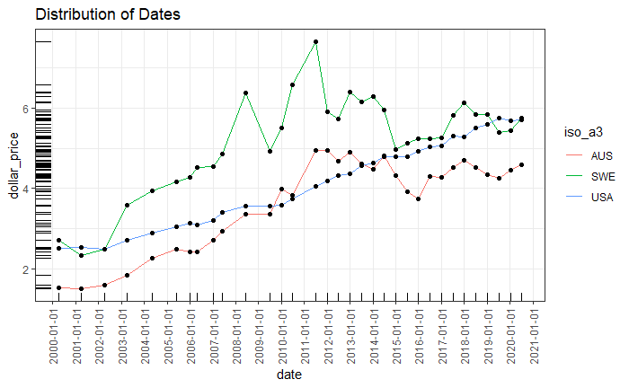

```r
big_mac %>%
  filter(iso_a3 %in% c("USA", "SWE", "AUS")) %>%
  ggplot(aes(x = date, y = dollar_price, group = iso_a3)) +
  geom_line(aes(color = iso_a3)) + geom_point() +
  geom_rug() +
  scale_x_date(date_breaks = "year", date_minor_breaks = "year") +
  labs(title = "Distribution of Dates") +
  theme_bw() +
  theme(
    axis.text.x = element_text(angle = 90, vjust = 0.5)
  )
```

```r
big_mac %>%
  janitor::tabyl(date)
```

```
       date  n    percent
 2000-04-01 28 0.02020202
 2001-04-01 28 0.02020202
 2002-04-01 32 0.02308802
 2003-04-01 31 0.02236652
 2004-05-01 39 0.02813853
 2005-06-01 40 0.02886003
 2006-01-01 31 0.02236652
 2006-05-01 40 0.02886003
 2007-01-01 40 0.02886003
 2007-06-01 40 0.02886003
 2008-06-01 40 0.02886003
 2009-07-01 41 0.02958153
 2010-01-01 41 0.02958153
 2010-07-01 41 0.02958153
 2011-07-01 42 0.03030303
 2012-01-01 42 0.03030303
 2012-07-01 40 0.02886003
 2013-01-01 42 0.03030303
 2013-07-01 42 0.03030303
 2014-01-01 42 0.03030303
 2014-07-01 43 0.03102453
 2015-01-01 43 0.03102453
 2015-07-01 43 0.03102453
 2016-01-01 43 0.03102453
 2016-07-01 43 0.03102453
 2017-01-01 43 0.03102453
 2017-07-01 43 0.03102453
 2018-01-01 43 0.03102453
 2018-07-01 56 0.04040404
 2019-01-01 56 0.04040404
 2019-07-09 56 0.04040404
 2020-01-14 56 0.04040404
 2020-07-01 56 0.04040404
```

This is fairly clear, but it’s hard to find a pattern in the early dates. Also, the early dates have fewer observations than the later ones, so some countries evidently only have data for some of the dates. That’s generally okay. Now, some more key terms.

**Overvalued** The currency costs too much relative to its purchasing power; the cost of a big mac in that country is greater than the cost of a big mac in America.

**Undervalued** The currency is too cheap relative to its purchasing power; the cost of a big mac in that country is less than the cost of a big mac in America.

**Big Mac Exchange Rate** The exchange rate that would exist if a big mac cost the same in local dollars as it did in US dollars. If the Big Mac exchange rate is less than the average exchange rate, the currency is ‘undervalued’. In other words, the dollar has too much buying power, and hence can buy more big macs.

What is the adjusted index? What is the variable `adj_price`? The latter is easier to answer. The `adj_price` is the GDP-adjusted price of a Big Mac, in dollars. This accounts for the trend that the price of a Big Mac increases with GDP.

[figure not shown]

```r
big_mac %>%
  ggplot(aes(x = gdp_dollar, y = dollar_price)) + geom_point(size = 0.5) +
  geom_smooth(method = 'lm', se = FALSE) +
  labs(title = "Price of a Big Mac",
       subtitle = "as a function of GDP per capita") +
  theme_bw()
```

This is a linear model showing Big Mac price in dollars as a function of GDP. As you can see, this linear model does a fairly good job explaining the relationship between GDP and big mac prices. The above graph shows the prices over the entire time series; for only 2020, you get the following graph:

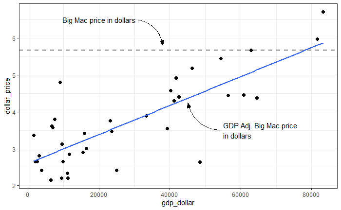

```r
bm_usd_2020 <- big_mac %>%
  filter(iso_a3 == "USA" & date == ymd('2020-01-14')) %>%
  pull(dollar_price)

big_mac %>%
  filter(date == ymd('2020-01-14')) %>%
  ggplot(aes(x = gdp_dollar, y = dollar_price)) +
  geom_point(size = 2) +
  geom_smooth(method = 'lm', se = FALSE) +
  geom_hline(yintercept = bm_usd_2020, linetype = 'dashed', size = 1, color = grey(0.5)) +
  annotate('text', x = 20000, y = 6.5, label = "Big Mac price in dollars") +
  annotate('curve', x = 31000, xend = 38000, y = 6.5, yend = 5.8, curvature = -.35,
           arrow = arrow(length = unit(3, 'mm'), angle = 20, type = 'closed')) +
  annotate('text', x = 55000, y = 3.5, label = "GDP Adj. Big Mac price\nin dollars", hjust = 0) +
  annotate('curve', x = 54000, y = 3.5, xend = 45000, yend = 4.25, curvature = -.35,
           arrow = arrow(length = unit(3, 'mm'), angle = 20, type = 'closed')) +
  theme_bw()
```

The GDP-adjusted price of a Big Mac uses the residuals of this model to determine the difference in price valuation. For example, if the predicted price, given a certain GDP, is $4, and the local market price is $3, then the currency is undervalued even accounting for changes in GDP.

Now every variable has been explained. The variables `[currency]_raw` and `[currency]_adjusted` give the index of the country relative to `[currency]`. The potential currencies are: US Dollar, Euro, Great British Pound, Japanese Yen, and the Chinese Yuan. These variables can be derived from the data with the appropriate country’s data. You need the exchange rate between the two countries, the price of a Big Mac in the reference country, and the price of a big mac in the comparison country.

# Ideas for a Graphic

So, how do I visualize the data for between 28 and 56 countries between 2000 and 2020? Spark lines are an obvious choice, as are small multiples in general. Let’s look at some lines then for the countries I have.

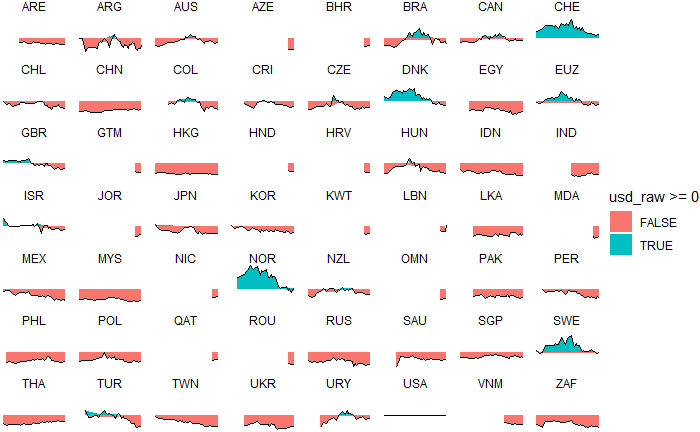

```r
big_mac %>%
  ggplot(aes(x = date, y = usd_raw)) +
  geom_area(aes(fill = usd_raw >= 0)) +
  geom_line() +
  facet_wrap(vars(iso_a3)) +
  theme_void()
```

Naturally, `geom_area` has a hard time filling observations where the line crosses an axis, so the results are a little weird. Is there a simple way to correct this? The problem is that the area chart has to choose what color to color the in-betweens, the areas between points. I would need to add an observation every time a time series shifts from positive to negative, with x interpolated to the exact moment the line crosses the boundary. This is a pretty simple interpolation problem, I think. Let’s make a basic example.

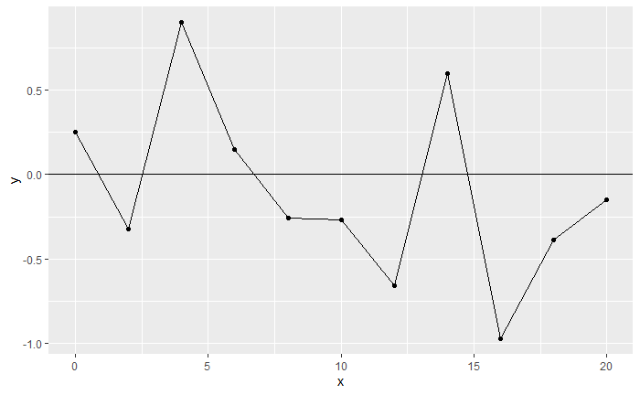

```r
df <- data.frame(
  x = seq(0, 20, 2),
  y = round(runif(n = 11, min = -1, max = 1), 2)
)

ggplot(df, aes(x = x, y = y)) +
  geom_line() + geom_point() + geom_hline(yintercept = 0)
```

If I use `geom_area` here, it won’t work.

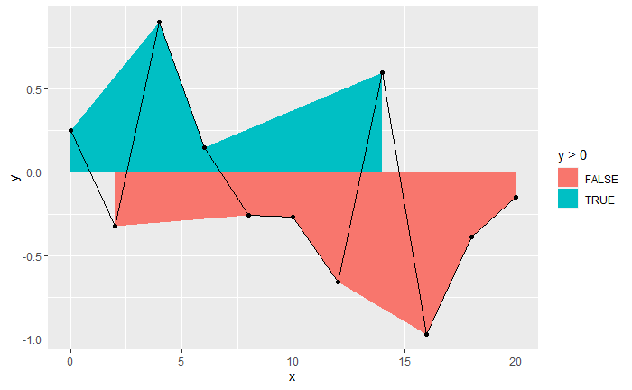

```r
ggplot(df, aes(x = x, y = y)) +
  geom_area(aes(fill = y > 0)) +
  geom_line() + geom_point() + geom_hline(yintercept = 0)
```

If I can introduce points that interpolate between those points that switch between above and below zero on the y-axis, then the plot will be fixed. How to do this, though? There’s an equation for it that I just derived (clumsily… need to re-up on my algebra skills). When y = 0, the formula for x is:

```
x = -((y1 * (x2 - x1)) / (y2 - y1)) + x1
```

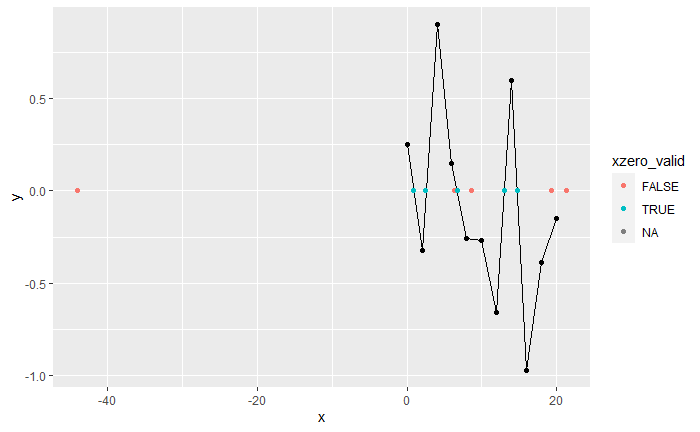

```r
df %>%
  mutate(
    ylead = lead(y),
    xlead = lead(x),
    xzero = -((y * (xlead - x)) / (ylead - y)) + x,
    xzero_valid = xzero > x & xzero < xlead
  ) %>%
  ggplot() +
  geom_line(aes(x = x, y = y)) + geom_point(aes(x = x, y = y)) +
  geom_point(aes(x = xzero, y = 0, color = xzero_valid))
```

Ah good. Now, to incorporate these points back into the dataset, I pivot longer and combine the columns.

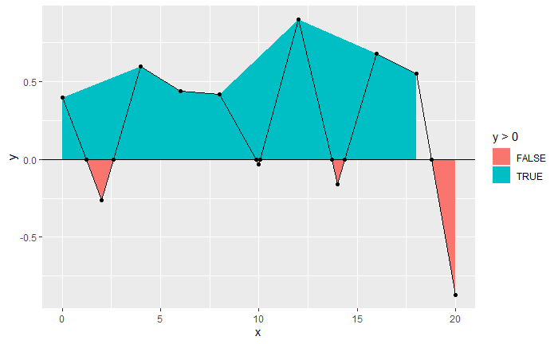

```r
df <- data.frame(
  x = seq(0, 20, 2),
  y = round(runif(n = 11, min = -1, max = 1), 2)
)

df_inbetween <- df %>%
  mutate(
    ylead = lead(y),
    xlead = lead(x),
    xzero = -((y * (xlead - x)) / (ylead - y)) + x,
    xzero_valid = xzero > x & xzero < xlead,
    yzero = 0,
    xzero = replace(xzero, !xzero_valid, NA),
    yzero = replace(yzero, !xzero_valid, NA)
  ) %>%
  select(x = xzero, y = yzero) %>% filter(!is.na(x))

df <- rbind(df, df_inbetween)

df %>%
  ggplot(aes(x = x, y = y)) +
  geom_area(aes(fill = y > 0)) +
  geom_line() + geom_point() +
  geom_hline(yintercept = 0)
```

Well that was a huge let-down. It works perfectly with values below zero and not at all for values above zero. A solution was proposed in [this](https://stackoverflow.com/questions/17959817/filling-area-under-curve-based-on-value) Stack Exchange post.

```r
# create some fake data with zero-crossings
yvals = c(2,2,-1,2,2,2,0,-1,-2,2,-2)
d = data.frame(x=seq(1,length(yvals)),y=yvals)

rx <- do.call("rbind",
   sapply(1:(nrow(d)-1), function(i){
   f <- lm(x~y, d[i:(i+1),])
   if (f$qr$rank < 2) return(NULL)
   r <- predict(f, newdata=data.frame(y=0))
   if(d[i,]$x < r & r < d[i+1,]$x)
      return(data.frame(x=r,y=0))
    else return(NULL)
 }))
 d2 <- rbind(d,rx)
 ggplot(d2,aes(x,y)) + geom_area(data=subset(d2, y<=0), fill="pink")
     + geom_area(data=subset(d2, y>=0), fill="lightblue") + geom_point()
```

This is just horrific to look at and try to figure out. The essence, though, is that you do two geom_areas, one for the data where y<=0 and one where y>=0 (notice how they both contain y=0).

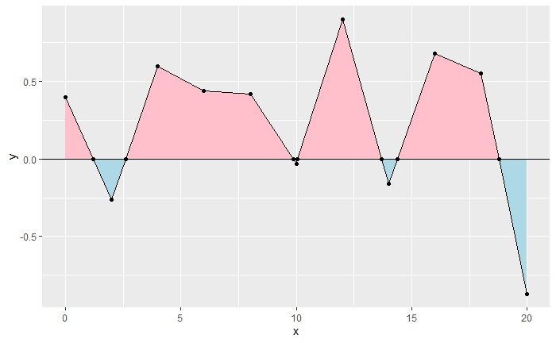

And voila… It’s not the best, but it’ll do. Let’s adapt this to the burger data. The problem is x-values for burgers are dates, not raw numerics. But I think I can easily convert.

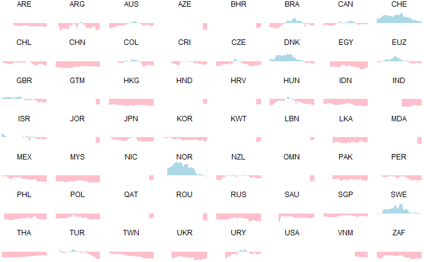

Since I’m short on time this week, I might be satisfied with this graphic and a more flexible function for generating the inbetweens.